# ENV 797 - Time Series Analysis for Energy and Environment Applications | Spring 2026

### Q3

Now plot both series in the same graph, also using ggplot(). Use function `scale_color_manual()` to manually add a legend to ggplot. Make the solar energy consumption red and wind energy consumption blue. Add informative name to the y axis using `ylab("Energy Consumption)`. And use function `scale_x_date()` to set x axis breaks every 5 years.

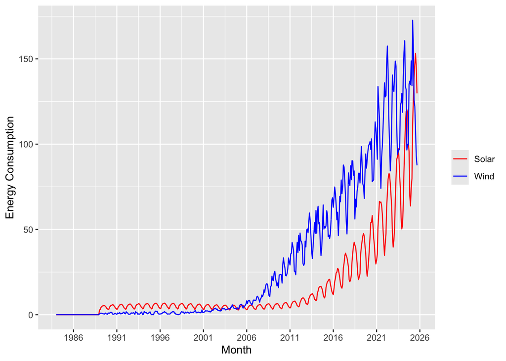

```r
ggplot(enery_data_clean, aes(x = Month)) +
  geom_line(aes(y = `Solar Energy Consumption`, colour = "Solar")) +
  geom_line(aes(y = `Wind Energy Consumption`,  colour = "Wind")) +
  scale_color_manual(values = c("Solar" = "red", "Wind" = "blue")) +
  ylab("Energy Consumption") +
  scale_x_date(date_breaks = "5 years", date_labels = "%Y") +
  labs(color = NULL)
```

## Decomposing the time series

The stats package has a function called decompose(). This function only take time series object. As the name says the decompose function will decompose your time series into three components: trend, seasonal and random. This is similar to what we did in the previous script, but in a more automated way. The random component is the time series without seasonal and trend component.

Additional info on `decompose()`.

1. You have two options: alternative and multiplicative. Multiplicative models exhibit a change in frequency over time.
2. The trend is not a straight line because it uses a moving average method to detect trend.
3. The seasonal component of the time series is found by subtracting the trend component from the original data then grouping the results by month and averaging them.
4. The random component, also referred to as the noise component, is composed of all the leftover signal which is not explained by the combination of the trend and seasonal component.

### Q4

Transform wind and solar series into a time series object and apply the decompose function on them using the additive option, i.e., `decompose(ts_data, type = "additive")`. What can you say about the trend component? What about the random component? Does the random component look random? Or does it appear to still have some seasonality on it?

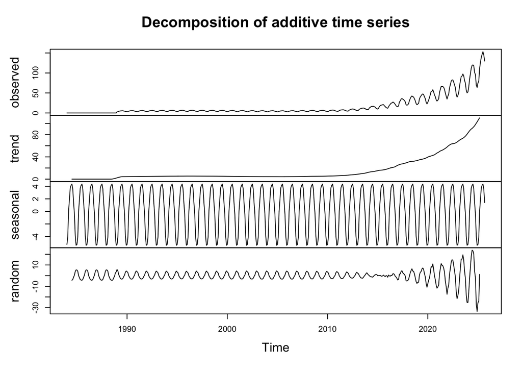

```r
# Use automate process
start_year  <- year(min(enery_data_clean$Month))
start_month <- month(min(enery_data_clean$Month))

# Time series for the solar and wind energy
solar_timser <- ts( enery_data_clean$`Solar Energy Consumption`, start = c(start_year, start_month),frequency = 12)

wind_timser <- ts(enery_data_clean$`Wind Energy Consumption`,start = c(start_year, start_month),frequency = 12)

# Apply decompose function
solar_dec_add <- decompose(solar_timser, type = "additive")
wind_dec_add  <- decompose(wind_timser,  type = "additive")

plot(solar_dec_add)
```

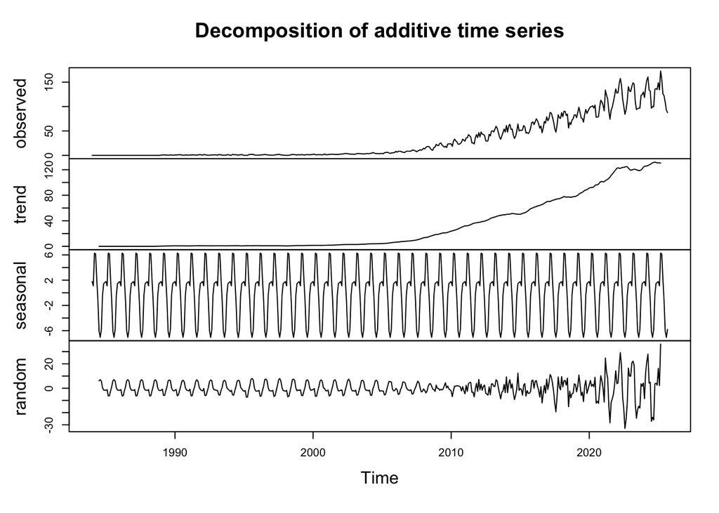

```r
plot(wind_dec_add)
```

### Q5

Use the decompose function again but now change the type of the seasonal component from additive to multiplicative. What happened to the random component this time?

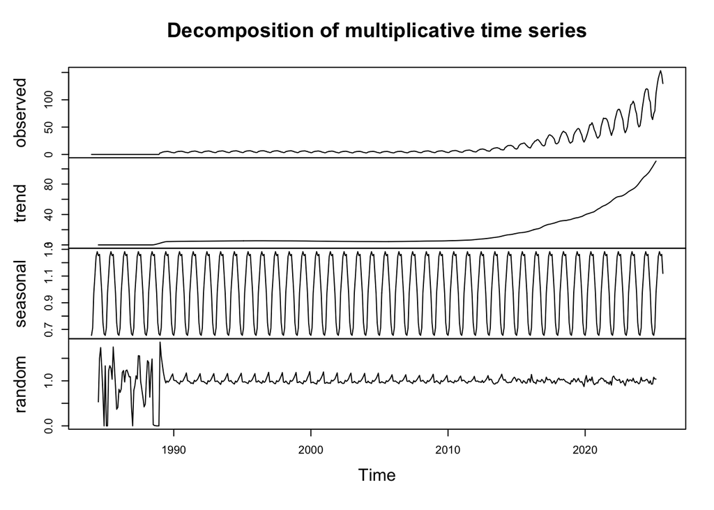

```r
solar_multiplicative <- decompose(solar_timser, type = "multiplicative")
wind_multiplicative  <- decompose(wind_timser,  type = "multiplicative")

# Plot the new results
plot(solar_multiplicative)
```

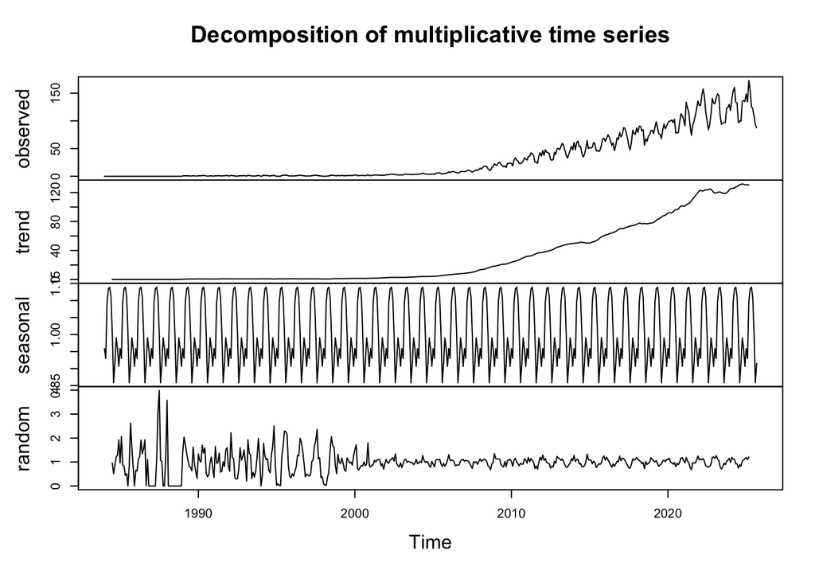

```r
plot(wind_multiplicative)
```

### Q6

When fitting a model to this data, do you think you need all the historical data? Think about the data from 80s, 90s and early 20s. Are there any information from those years we might need to forecast the next six months of Solar and/or Wind consumption. Explain your response.

> Answer: Theoretically, historical data is not fitting in the model because it technically contains no relevant information, mostly because there are no information to use to train the model, hence we do not need it. However, the recent data in earl or late 90s through 20s also the same but the data within a couple years of it represent more current data.

### Q7

Create a new time series object where historical data starts on January 2014. Hint: use `filter()` function so that you don’t need to point to row numbers, .i.e, `filter(xxxx, year(Date) >= 2014 )`. Apply the decompose function `type=additive` to this new time series. Comment on the results. Does the random component look random?

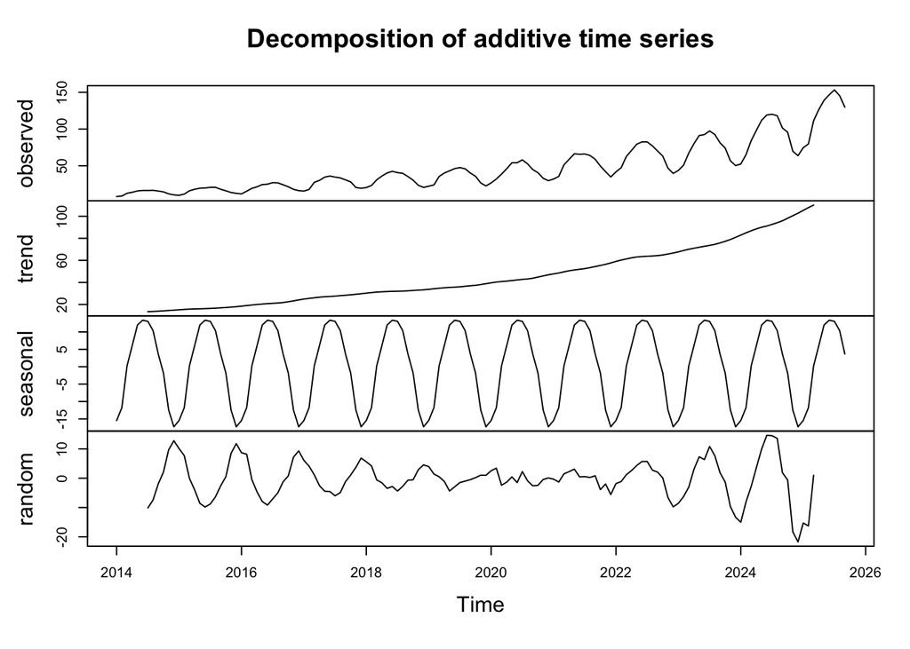

```r
recent_energy <- enery_data_clean %>%
  filter(year(Month) >= 2014)

recent_solar_timser <- ts(recent_energy$`Solar Energy Consumption`, start = c(2014, 1), frequency = 12)

recent_wind_timser <- ts(recent_energy$`Wind Energy Consumption`, start = c(2014, 1), frequency = 12)

recent_decomp_solar <- decompose(recent_solar_timser, type = "additive")
recent_decomp_wind  <- decompose(recent_wind_timser,  type = "additive")

plot(recent_decomp_solar)
```

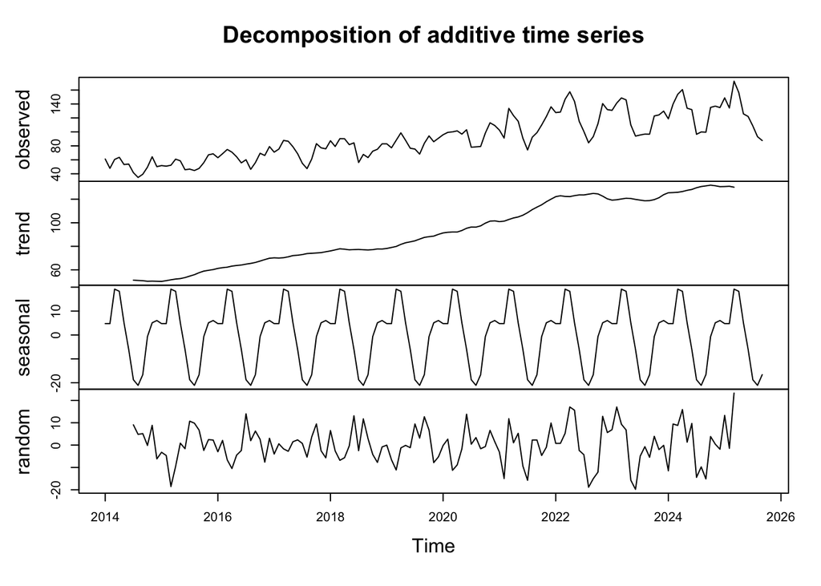

```r
plot(recent_decomp_wind)
```

> Answer: For the 2014 onward, the trend still shows the recent growth period clearly and smoothly. The seasonal pattern stay consistent across years.

## Identify and Remove outliers

### Q8

Apply the `tsclean()` to both time series object you created on Q4. Did the function removed any outliers from the series? Hint: Use `autoplot()` to check if there is difference between cleaned series and original series.

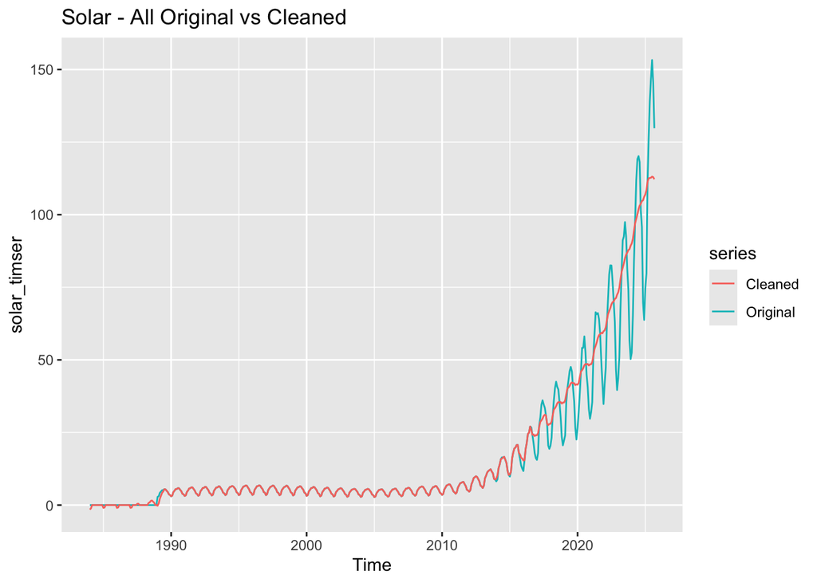

```r
solar_original <- tsclean(solar_timser)
wind_original  <- tsclean(wind_timser)

autoplot(solar_timser, series = "Original") +
  autolayer(solar_original, series = "Cleaned") +
  ggtitle("Solar - All Original vs Cleaned")
```

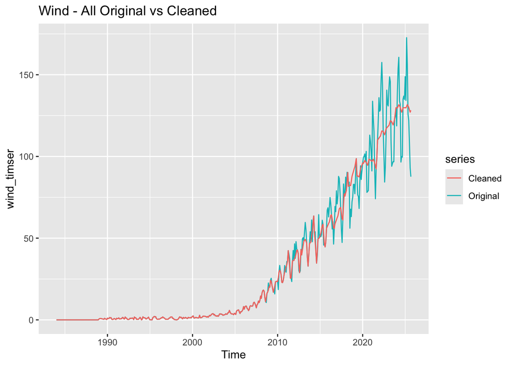

```r
autoplot(wind_timser, series = "Original") +
  autolayer(wind_original, series = "Cleaned") +
  ggtitle("Wind - All Original vs Cleaned")
```

### Q9

Redo number Q8 but now with the time series you created on Q7, i.e., the series starting in 2014. Using what `autoplot()` again what happened now? Did the function removed any outliers from the series?

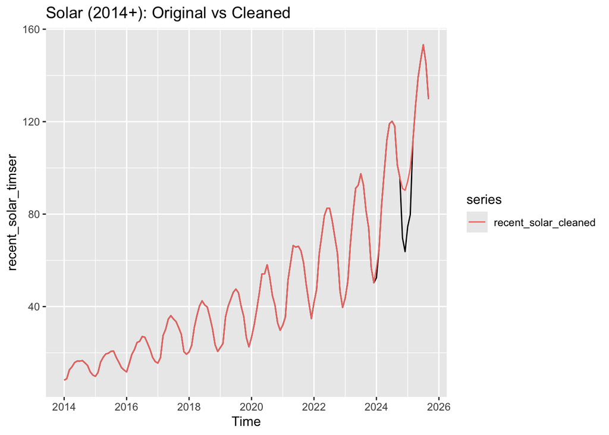

```r
recent_solar_cleaned <- tsclean(recent_solar_timser)
recent_wind_cleaned  <- tsclean(recent_wind_timser)

autoplot(recent_solar_timser) +
  autolayer(recent_solar_cleaned) +
  ggtitle("Solar (2014+): Original vs Cleaned")
```

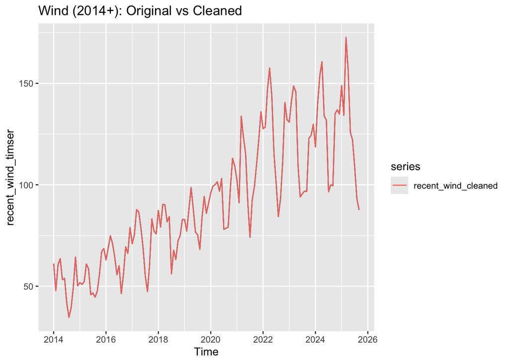

```r
autoplot(recent_wind_timser) +
  autolayer(recent_wind_cleaned) +
  ggtitle("Wind (2014+): Original vs Cleaned")
```